# Heart Failure Prevision

Lajoie BENGONE AKOU & Jean-Luc AYIVOR

2026-01-06

# 1 PRESENTATON DE LA BASE DE DONNEES

La base de données [**Heart Failure Clinical Records**](https://archive.ics.uci.edu/dataset/519/heart+failure+clinical+records) contient les dossiers médicaux de 299 patients atteints d’insuffisance cardiaque, recueillis pendant leur période de suivi, chaque profil de patient comportant 13 caractéristiques cliniques qui se présentent comme suit :

- age : age of the patient (year)
- anaemia : decrease of red blood cells or hemoglobin (.)
- creatinine_phosphokinase : level of the CPK enzyme in the blood (mcg/L)
- diabetes : if the patient has diabetes (.)
- ejection_fraction : percentage of blood leaving the heart at each contraction (%)
- high_blood_pressure : if the patient has hypertension (.)
- platelets : platelets in the blood (kiloplatelets/mL)
- serum_creatinine : level of serum creatinine in the blood (mg/dL)
- serum_sodium : level of serum sodium in the blood (mEq/L)
- sex : Sex woman or man (.)
- smoking : if the patient smokes or not (.)
- time : follow-up period (days)
- DEAHT_EVENT : if the patient died during the follow-up period (.)

# 2 OBJECTIF

L’objectif de cette étude est de prédire si un patient atteint d’insuffissance cardiaque va décéder pendant la période de suivi ou pas selon le niveau de sévérité de ses caractéristiques médicales. [source](http://heart.org/en/health-topics/heart-failure/what-is-heart-failure/classes-of-heart-failure#:~:text=Heart%20failure%20can%20progress.,how%20bad%20the%20symptoms%20are)

# 3 ORGANISATION DU REPERTOIRE DE TRAVAIL

## 3.1 Définition du répertoire de travail

```r
# Chargement du répertoire de travail
setwd("C:/Users/lajoi/Documents/0_PARCOURS UNIVERSITAIRE/3_MASTER_2024_2026/UPEC - M2 - S1 - MASERATI DA/Scoring/HeartFailurePrediction")
```

## 3.2 Création des dossiers pour les inputs et outputs

```r
data_input_url <- "data_input"
data_input <- ifelse(dir.exists(data_input_url)==TRUE, print("Le dossier existe déjà"), dir.create(data_input_url))
```

```
## [1] "Le dossier existe déjà"
```

```r
data_output_url <- "data_output"
data_output <- ifelse(dir.exists(data_output_url)==TRUE, print("Le dossier existe déjà"), dir.create(data_output_url))
```

```
## [1] "Le dossier existe déjà"
```

# 4 INSTALLATION ET CHARGEMENT DES PACKAGES AVEC PACMAN

## 4.1 Installation du package avec pacman

```r
#install.packages("pacman", repos = "http://cran.us.r-project.org") # install.packages("pacman")
```

## 4.2 Chargement du package avec la méthode pacman

```r
library(pacman)
```

### 4.2.1 Chargement des librairies

```r
p_load("tidyverse",
       "ggplot2",
       "stargazer",
       "cluster",
       "factoextra",
       "dendextend",
       "clue",
       "caret",
       "flexclust",
       "MASS",
       "caret",
       "candisc",
       "klaR",
       "class",
       "pROC",
       "rpart",
       "rpart.plot",
       "tree",
       "ggcorrplot")
```

# 5 CHARGEMENT DE LA BASE DE DONNES

```r
HeartFailure <- read.csv("Data_input/heart_failure_clinical_records_dataset.csv", sep = ",")
HeartFailure |> head(5)
```

```
##   age anaemia creatinine_phosphokinase diabetes ejection_fraction
## 1  75       0                      582        0                20
## 2  55       0                     7861        0                38
## 3  65       0                      146        0                20
## 4  50       1                      111        0                20
## 5  65       1                      160        1                20
##   high_blood_pressure platelets serum_creatinine serum_sodium sex smoking time
## 1                   1    265000              1.9          130   1       0    4
## 2                   0    263358              1.1          136   1       0    6
## 3                   0    162000              1.3          129   1       1    7
## 4                   0    210000              1.9          137   1       0    7
## 5                   0    327000              2.7          116   0       0    8
##   DEATH_EVENT
## 1           1
## 2           1
## 3           1
## 4           1
## 5           1
```

# 6 ANALYSE DESCRIPTIVE

## 6.1 Tableau de statistiques descriptives

```r
stargazer(HeartFailure, type = "text", out = "Data_output/tab1_stats.txt")
```

```
##
## ==========================================================================
## Statistic                 N     Mean      St. Dev.     Min         Max
## --------------------------------------------------------------------------
## age                      299   60.834      11.895     40.000     95.000
## anaemia                  299    0.431      0.496        0           1
## creatinine_phosphokinase 299   581.839    970.288       23        7,861
## diabetes                 299    0.418      0.494        0           1
## ejection_fraction        299   38.084      11.835       14         80
## high_blood_pressure      299    0.351      0.478        0           1
## platelets                299 263,358.000 97,804.240 25,100.000 850,000.000
## serum_creatinine         299    1.394      1.035      0.500       9.400
## serum_sodium             299   136.625     4.412       113         148
## sex                      299    0.649      0.478        0           1
## smoking                  299    0.321      0.468        0           1
## time                     299   130.261     77.614       4          285
## DEATH_EVENT              299    0.321      0.468        0           1
## --------------------------------------------------------------------------
```

### 6.1.1 Commentaire :

La base de données contient 299 observations. Il est important de souligner qu’il n’y a 0 valeur manquante. Les variables sont toutes numériques (continue, discrète ou binaire). Les variances sont très différentes d’une variables à l’autre.

On remarque que l’étude porte sur des patients agés de 40 à 95 ans ce qui semble logique car les insuffisances cardiaques atteigent plus les personnes agées. Dans notre cas, la plupart des patients ont environ 61 ans.

Plus de la moitié des patients ne sont pas anémiés (170 contre 129 patient anémiés). 41.8% des patients déclarent avoir le diabète et ceux souffrant d’hypertension représentent environ 35%.

La plupart des patient ont déclaré qu’à chaque contraction, environ 38% de sang quittent leurs coeurs.

Les femmes sont les plus représentées (65%). 32% des patients fumaient encore et 32% sont morts au cours de la période de suivi.

On remarque également qu’il y’a une disproportionnalité des valeurs des variables, ce qui pourraît influencer nos résultats des méthodes de scoring qui seront appliquées

## 6.2 Nuages de points

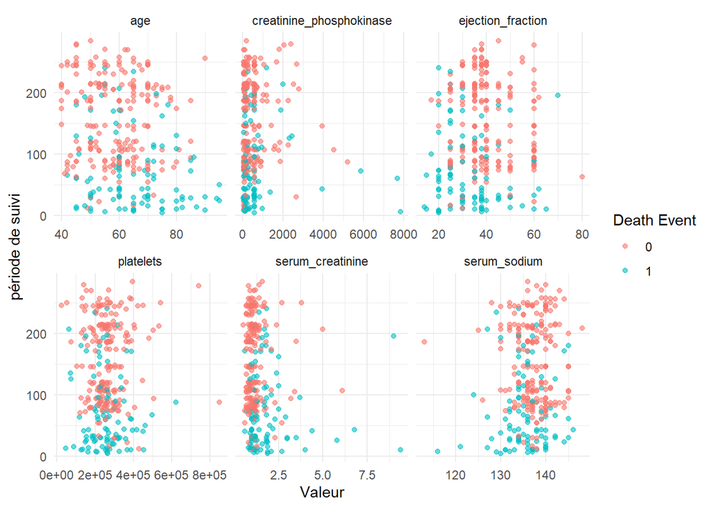

```r
# Tranformation tibble
HeartFailure_tibble <- as_tibble(HeartFailure)

# Sélection des variables à comparer
vars <- c("platelets", "age", "serum_creatinine", "serum_sodium", "creatinine_phosphokinase", "ejection_fraction")

# Transformation en format tidy pour pourvoir juxtaposer les nuages de points
HeartFailure_long <- HeartFailure_tibble %>%
  dplyr::select(all_of(vars), time, DEATH_EVENT) %>%
  pivot_longer(cols = all_of(vars), names_to = "Variable", values_to = "Valeur")

# Nuages de points juxtaposés
ggplot(HeartFailure_long, aes(x = Valeur, y = time, color = factor(DEATH_EVENT))) +
  geom_point(alpha = 0.6) +
  facet_wrap(~ Variable, scales = "free_x") +  # un nuage pour chaque variable
  labs(x = "Valeur", y = "période de suivi", color = "Death Event") +
  theme_minimal()
```

```r
# ggsave("data_output/im1_scatterplots.png")
```

### 6.2.1 Commentaire :

Sur tous les panneaux, l’axe vertical correspond à la période de suivi (time). Les points bleus (patients décédés) sont très majoritairement concentrés en bas du graphique, alors que les points rouges (survivants) s’étendent beaucoup plus vers le haut.

## 6.3 Matrice de correlation

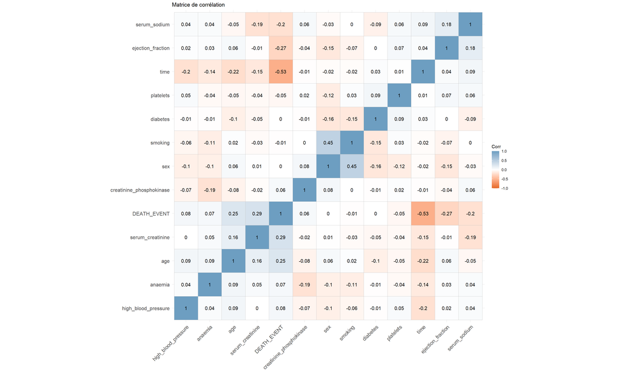

```r
cor_matrix <- round(cor(HeartFailure, method = "pearson", use = "complete.obs"),3)
cor_plot <- ggcorrplot(corr = cor_matrix,
                      hc.order = TRUE,
                      type = "full",
                      lab_size = 4,
                      colors = c("#E46726", "white","#6D9EC1"),
                      title = "Matrice de corrélation",
                      lab = TRUE,
                      ggtheme = )
cor_plot
```

# 7 PREPARATION DE LA BASE DE DONNEES :

```r
# Critère de séparation : Méthode train test split
set.seed(123)
idx_train <- sample(nrow(HeartFailure), size = floor(0.7 * nrow(HeartFailure)))
length(idx_train)
```

```
## [1] 209
```

```r
# Base d'entrainement
HeartFailure_Train <- HeartFailure[idx_train, ]
HeartFailure_Train_labels <- HeartFailure_Train$DEATH_EVENT
HeartFailure_Train_no_death <- subset(HeartFailure_Train, select=-DEATH_EVENT)
HeartFailure_Train |> head(5)
```

```
##     age anaemia creatinine_phosphokinase diabetes ejection_fraction
## 179  63       1                      122        1                60
## 14   50       1                      168        0                38
## 195  45       0                      582        0                20
## 118  85       1                      102        0                60
## 229  65       0                       56        0                25
##     high_blood_pressure platelets serum_creatinine serum_sodium sex smoking
## 179                   0    267000              1.2          145   1       0
## 14                    1    276000              1.1          137   1       0
## 195                   1    126000              1.6          135   1       0
## 118                   0    507000              3.2          138   0       0
## 229                   0    237000              5.0          130   0       0
##     time DEATH_EVENT
## 179  147           0
## 14    11           1
## 195  180           1
## 118   94           0
## 229  207           0
```

```r
# Base test
HeartFailure_Test <- HeartFailure[-idx_train, ]
HeartFailure_Test_labels <- HeartFailure_Test$DEATH_EVENT
HeartFailure_Test_no_death <- subset(HeartFailure_Test, select=-DEATH_EVENT)
HeartFailure_Test |> head(5)
```

```
##    age anaemia creatinine_phosphokinase diabetes ejection_fraction
## 2   55       0                     7861        0                38
## 3   65       0                      146        0                20
## 8   60       1                      315        1                60
## 12  62       0                      231        0                25
## 15  49       1                       80        0                30
##    high_blood_pressure platelets serum_creatinine serum_sodium sex smoking time
## 2                    0    263358              1.1          136   1       0    6
## 3                    0    162000              1.3          129   1       1    7
## 8                    0    454000              1.1          131   1       1   10
## 12                   1    253000              0.9          140   1       1   10
## 15                   1    427000              1.0          138   0       0   12
##    DEATH_EVENT
## 2            1
## 3            1
## 8            1
## 12           1
## 15           0
```

## 7.1 Affichage des modalités

```r
table(HeartFailure_Train_labels)
```

```
## HeartFailure_Train_labels
##   0   1
## 142  67
```

```r
cat("\n")
```

```r
table(HeartFailure_Test_labels)
```

```
## HeartFailure_Test_labels
##  0  1
## 61 29
```

La base de données a été séparée en deux bases. La première base de données est la base de données d’entrainement à partir de laquelle les algorithmes seront entrainés. La deuxième base de données quant à elle sera utilisée pour évaluer les capacités prédictives des algorithmes sur nouvelles données.

# 8 CLASSIFICATION ASCENDANTE HIERARCHIQUE

## 8.1 Standardisation des données

```r
col_scale <- c("age","creatinine_phosphokinase","ejection_fraction","platelets","serum_creatinine","serum_sodium","time")

# Création des variables standardisées
HeartFailure_Train_no_death_Scaled <- HeartFailure_Train_no_death

HeartFailure_Train_no_death_Scaled[col_scale] <- scale(HeartFailure_Train_no_death_Scaled[col_scale], center =TRUE, scale = TRUE)

HeartFailure_Train_no_death_Scaled |> head(5)
```

```
##            age anaemia creatinine_phosphokinase diabetes ejection_fraction
## 179  0.2106596       1              -0.48097968        1        1.96452699
## 14  -0.8837229       1              -0.43451480        0        0.01862111
## 195 -1.3046392       0              -0.01633085        0       -1.57348370
## 118  2.0626914       1              -0.50118180        0        1.96452699
## 229  0.3790261       0              -0.54764668        0       -1.13123236
##     high_blood_pressure   platelets serum_creatinine serum_sodium sex smoking
## 179                   0 -0.01655170       -0.2098185   1.87042421   1       0
## 14                    1  0.07112762       -0.2985699   0.08438807   1       0
## 195                   1 -1.39019439        0.1451871  -0.36212096   1       0
## 118                   0  2.32156352        1.5652096   0.30764259   0       0
## 229                   0 -0.30881610        3.1627350  -1.47839355   0       0
##           time
## 179  0.2389491
## 14  -1.5056923
## 195  0.6622812
## 118 -0.4409479
## 229  1.0086438
```

```r
# Création du fichier données finales
#write.csv(HeartFailure_Train_no_death_Scaled_df, file = #"data_ouput/df3_HeartFailure_Train_no_death_Scaled_df.csv", row.names = FALSE)
```

## 8.2 Vérification des données standardisées

```r
stargazer(HeartFailure_Train_no_death_Scaled, type = "text")
```

```
##
## =========================================================
## Statistic                 N   Mean  St. Dev.  Min    Max
## ---------------------------------------------------------
## age                      209 -0.000  1.000   -1.726 2.905
## anaemia                  209 0.455   0.499     0      1
## creatinine_phosphokinase 209 -0.000  1.000   -0.581 7.176
## diabetes                 209 0.426   0.496     0      1
## ejection_fraction        209 -0.000  1.000   -2.016 2.849
## high_blood_pressure      209 0.368   0.484     0      1
## platelets                209 -0.000  1.000   -2.160 5.663
## serum_creatinine         209 -0.000  1.000   -0.742 7.068
## serum_sodium             209 0.000   1.000   -5.274 2.540
## sex                      209 0.651   0.478     0      1
## smoking                  209 0.330   0.471     0      1
## time                     209 -0.000  1.000   -1.595 1.945
## ---------------------------------------------------------
```

## 8.3 CLASSIFICATION ASCENDANTE HIERARCHIQUE : Critère Linkage Complete

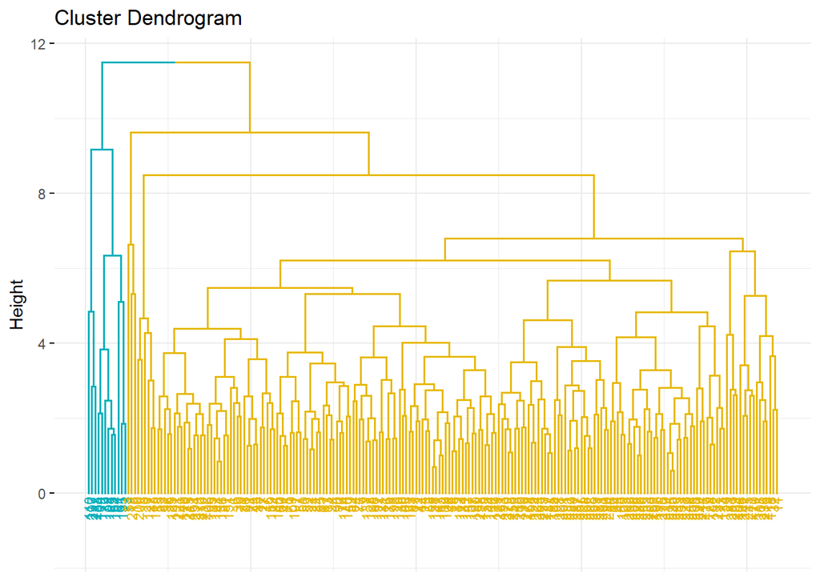

```r
# sauvegarder de l'image
#png("data_output/im3_dendo1.png")

# Dissimilarity matrix
d = dist(HeartFailure_Train_no_death_Scaled, method = "euclidean")

# Hierarchical clustering using Complete Linkage
hc1 <- hclust(d, method = "complete" )

fviz_dend(hc1, k = 2, cex = 0.6, k_colors = c("#00AFBB","#E7B800"),
          color_labels_by_k = TRUE, ggtheme = theme_minimal())
```

```r
#dev.off()

# # Plot the obtained dendrogram
# plot(hc1, cex = 0.6, hang = -1)  # hang : pour mettre les étiquettes à partir de 0

# plot(hc1, cex = 0.6, hang = -1)  # hang : pour mettre les étiquettes à partir de 0
```

Cette classification ascendante hierarchique (CAH) utilise les critères de distance euclidienne et de saut complet. Ces critères correspondent à la distance entre les individus pour le premier et les classes pour le second. Ces distances permettent de regrouper des individus qui se ressemblent en formant des classes ou des clusters. Plus la variance au sein des classes est faible, plus les individus se ressemblent. De plus, plus la variance entre les classes est forte, plus les individus sont différents d’une classe à l’autre. L’objectif est par conséquent d’atteindre la classification optimale, c’est à dire, celle qui minimise la variance intra-groupe et qui maximise la variance inter-groupe et de le présenter sous la forme d’un dendogramme.

Ainsi, on peut remarquer, que l’Algorithme de CAH deployé a permis d’obtenir deux groupes disproportionnés en nombre d’individus.

## 8.4 CLASSIFICATION ASCENDANTE HIERARCHIQUE : distance de Ward

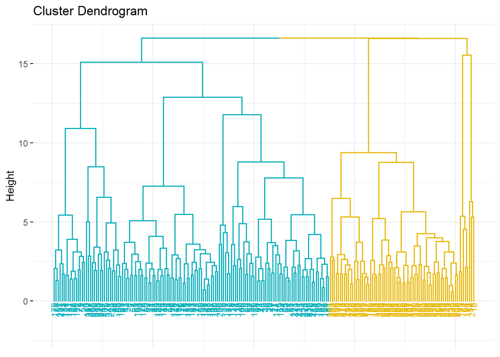

```r
# sauvegarder de l'image
#png("data_output/im4_dendo2.png")

# Classification Ascendante Hierarchique en utilisant le critère de Ward
hc2 <- hclust(d, method = "ward.D2" )

fviz_dend(hc2, k = 2, cex = 0.6, k_colors = c("#00AFBB","#E7B800"),
          color_labels_by_k = TRUE, ggtheme = theme_minimal())
```

```r
# # Dendogramme
# plot(hc2, cex = 0.6, hang = -1)
#
# # Diviser le dendongramme en 2 groupes
# sub_grp <- cutree(hc2, k = 2)
#
# # Paramétrage
# plot(hc2, cex = 0.6)
# rect.hclust(hc2, k = 2, border = 2:3)

#dev.off()

# # Plot the obtained dendrogram
# plot(hc2, cex = 0.6, hang = -1)
#
# # We can cut the tree into 2 groups
# sub_grp <- cutree(hc2, k = 2)
# #
# plot(hc2, cex = 0.6)
# rect.hclust(hc2, k = 2, border = 2:3)
```

C’est dans le but d’améliorer la classification, qu’on va utiliser le critère de Ward comme critère de distance entre les classes. Ce dernier est généralement plus robuste car il prend en compte la taille des cluster dans le calcul de la distance. Ainsi, on peut observer qu’avec la distance de WARD, on arrive à mieux distinguer les groupes. On peut distinguer 2 à 3 groupes qui se forment.

## 8.5 Evaluation des résultats de la CAH

```r
# Valeurs prédites : Clustering selon la cah
cah_train_prediction <- cutree(hc2, 2) # coder en 1 et 2

# Création des variables labels true et labels predict
HeartFailure_Train_no_death_Scaled$cluster_pred <- ifelse(cah_train_prediction==1,0,1)
HeartFailure_Train_no_death_Scaled$cluster_true <- HeartFailure_Train_labels

# Matrice de confusion cah
confusion_matrix_cah <- table(HeartFailure_Train_no_death_Scaled$cluster_pred, HeartFailure_Train_no_death_Scaled$cluster_true)
print(confusion_matrix_cah)
```

```
##
##      0  1
##   0 82 55
##   1 60 12
```

```r
# accuracy
accuracy_cah <- sum(diag(confusion_matrix_cah)) / sum(confusion_matrix_cah)
cat("accuracy in cah is : ", accuracy_cah)
```

```
## accuracy in cah is :  0.4497608
```

Notre modèle arrive à classer 82 individus comme survivants et qui ont bien survécu. Cependant, il déclare 55 survivants qui en réalité sont décédés.

Ces résultats sont logiques car base contient beaucoup plus de survivants que d’individus décédés. Ainsi, notre modèle est mieux entraîner sur cette catégories d’individus, ce qui explique pourquoi il arrive à mieux catégoriser les survivant.

# 9 METHODE DE KMEANS

```r
# Spécifier le nombre de clusters
kMeans_ncluster <- 2

# Appliquer l'algorithme K-Médian sur l'ensemble de données d'entraînement
kMeans_result <- kmeans(HeartFailure_Train_no_death, centers = kMeans_ncluster, nstart = 57)
kMeans_result
```

```
## K-means clustering with 2 clusters of sizes 166, 43
##
## Cluster means:
##        age   anaemia creatinine_phosphokinase  diabetes ejection_fraction
## 1 60.50602 0.4518072                 578.4880 0.4036145          37.74096
## 2 60.46512 0.4651163                 674.1395 0.5116279          37.97674
##   high_blood_pressure platelets serum_creatinine serum_sodium       sex
## 1           0.3614458  230946.3         1.410723     136.5181 0.6626506
## 2           0.3953488  414441.9         1.535581     137.0233 0.6046512
##     smoking     time
## 1 0.3253012 127.4337
## 2 0.3488372 132.0000
##
## Clustering vector:
## 179  14 195 118 229 244 298 153  90  91 256 197 290 137  26   7 286 254 211  78
##   1   1   1   2   1   1   1   1   1   1   2   1   2   1   1   1   2   1   2   1
##  81  43 143  32 109 263  23 135 224 166 217  69  72  76  63 141 210 292  41 291
##   1   1   2   2   1   1   1   1   1   1   2   1   1   1   1   1   1   1   1   1
## 223  16 116  94   6 235 200  86 252  39 159 240 209 296  50 241  34   4  13 268
##   2   1   1   1   1   1   1   2   1   1   1   1   1   1   2   2   1   1   1   1
## 127 262  52  22  89 160  25 215  35 168 112  30 140 249 121 110 158  64 142 199
##   1   1   2   1   1   2   1   1   1   1   1   1   1   1   1   2   1   2   2   1
##  67 151 122  79  85 165 136  51  74 178 106  98 281 239 204 174  17 190  46  54
##   1   1   1   1   1   2   1   1   1   1   2   1   1   1   1   1   1   1   1   2
## 163 271 289 216  24 113 107 272 218 154 102 234 192 155 170   5  70 258 297 276
##   2   1   1   1   2   1   1   1   1   1   1   2   1   1   1   2   2   1   2   2
##  21  55  75 164  83 250 253 283  48  77 175 111 205   1 228 288 182  88 173  20
##   1   1   1   1   1   1   1   1   2   1   1   1   1   1   1   2   1   1   1   1
## 104  93 237 108 236  42  59  84  11 225 213 201 232 275 193 185  36 221 220 125
##   1   1   1   1   2   1   1   1   2   2   2   1   1   1   1   1   1   1   2   1
##  33  40  10 227   9 284  61 265 161 285 139  57 149  29 115 172  53 131 144 145
##   1   2   2   1   1   1   2   1   1   1   1   1   1   1   2   2   1   1   1   2
## 191 233 157 130 134 246  87 260 180 152 181 128  73 105 101 273 293 255 287 270
##   2   1   1   1   1   1   1   1   1   1   1   1   1   1   1   1   2   1   1   1
## 295  58 279 126 257  27 147 206  60
##   1   1   1   1   1   1   1   2   1
##
## Within cluster sum of squares by cluster:
## [1] 533461925225 508349786700
##  (between_SS / total_SS =  52.5 %)
##
## Available components:
##
## [1] "cluster"      "centers"      "totss"        "withinss"     "tot.withinss"
## [6] "betweenss"    "size"         "iter"         "ifault"
```

Ici, on fixe le nombre de cluster égal à 2 car on connaît d’avantage le nombre de classe existante. Le ratio between_SS / total_SS mesure la part de la variabilité totale expliquée par la le clustering. Une valeur élevée indique que les groupes obtenus sont bien séparés et captent une part importante de nos données.

On remarque que le ratio between_SS / total_SS = 52.5 %. Ce qui implique que 52.5 % de la variabilité totale des données est expliquée par la séparation en deux clusters.

Nous allons comparer ce ration en augmentant le nombre de cluster (k à 3)

```r
# Spécifier le nombre de clusters
kMeans_ncluster <- 3

# Appliquer l'algorithme K-Médian sur l'ensemble de données d'entraînement
kMeans_result_k3 <- kmeans(HeartFailure_Train_no_death, centers = kMeans_ncluster, nstart = 57)
kMeans_result_k3
```

```
## K-means clustering with 3 clusters of sizes 110, 88, 11
##
## Cluster means:
##        age   anaemia creatinine_phosphokinase  diabetes ejection_fraction
## 1 60.05455 0.4363636                 592.1091 0.4181818          38.52727
## 2 60.81818 0.5000000                 617.6932 0.4090909          36.44318
## 3 62.36364 0.2727273                 502.5455 0.6363636          41.18182
##   high_blood_pressure platelets serum_creatinine serum_sodium       sex
## 1           0.4090909  302728.1         1.367909     136.5818 0.6272727
## 2           0.3295455  189556.8         1.530795     136.5568 0.6931818
## 3           0.2727273  561545.5         1.366364     137.5455 0.5454545
##     smoking     time
## 1 0.3363636 127.1545
## 2 0.3068182 127.3409
## 3 0.4545455 148.8182
```

[output cut: 33 more lines]

Avec un k=3, on remarque que le ratio between_SS / total_SS passe de 52.5 % à 74.0 %, ce qui constitue une grande amélioration. Cependant, vu qu’on connaît déjà le nombre de classe (2 pour mort ou survi), nous allons retenir un k =2

Pour confirmer le nombre de K utilisé, on va utiliser la méthode du coude

## 9.1 Méthode du Coude

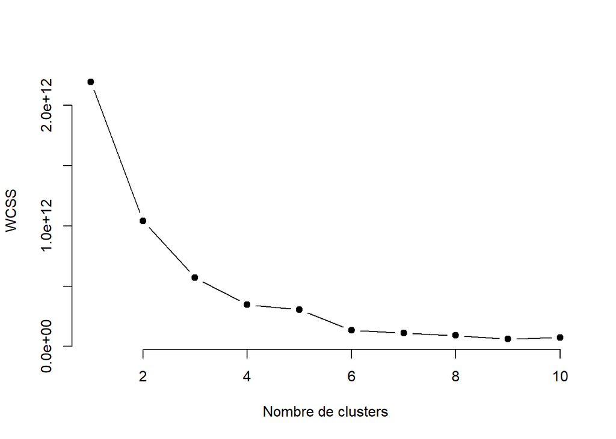

```r
# Définir le nombre maximum de clusters à tester :10 c'est bien étant donné le nbr d'obsr que vous avons
max_clusters <- 10

# Stocker les valeurs de WCSS (Within-Cluster Sum of Squares) pour chaque nombre de clusters
wcss_values <- numeric(max_clusters)

# Calculer WCSS pour chaque nombre de clusters
for (k in 1:max_clusters) {
  kmeans_result_coude <- kmeans(HeartFailure_Train_no_death, centers = k)
  wcss_values[k] <- kmeans_result_coude$tot.withinss
}

# Créer un graphique pour visualiser les valeurs de WCSS
plot(1:max_clusters, wcss_values, type = "b", pch = 19, frame = FALSE,
     xlab = "Nombre de clusters", ylab = "WCSS")
```

```r
#ggsave("data_output/im5_CoudeGraph.png")
```

On remarque qu’il une déclinaison (aussi appelée saut) importante de la courbe en 2, ce qui confirme qu’on a effectivement 2 groupes.

## 9.2 Prévision et Evaluation kMeans

```r
#kMeans sur les données d'entrainement
kmean_test_prediction <- cl_predict(kMeans_result, newdata = HeartFailure_Test_no_death)

#Prédire les clusters pour les données de test
kmean_test_prediction_recode <- ifelse(kmean_test_prediction==1,1,0)

#Créer la matrice de confusion entre les clusters prédits et les vraies étiquettes
confusion_matrix_kMeans <- table(kmean_test_prediction_recode, HeartFailure_Test_labels)
print(confusion_matrix_kMeans)
```

```
##                             HeartFailure_Test_labels
## kmean_test_prediction_recode  0  1
##                            0 11  5
##                            1 50 24
```

```r
# Calculer la précision en utilisant la matrice de confusion
accuracy_kMeans <- sum(diag(confusion_matrix_kMeans)) / sum(confusion_matrix_kMeans)
cat("accuracy kMeans is : ", accuracy_kMeans)
```

```
## accuracy kMeans is :  0.3888889
```

Notre modèle arrive à classer 11 individus comme survivants et qui ont bien survécu. Cependant, il déclare 5 survivants qui en réalité sont décédés.

Pour les non survivants, notre modèle catégorise 50 non survivants qui en réalité ont survécu et il arrive à classer 24 non survivants qui sont bien décédés.

En général, notre modèle arrive à être précis à 38,89%

# 10 METHODE KNN

```r
knn_nb_cluster <- 2
knn_result <- knn(HeartFailure_Train_no_death, HeartFailure_Test_no_death, HeartFailure_Train_labels, knn_nb_cluster)
knn_result
```

```
##  [1] 1 0 0 0 0 0 0 0 1 0 1 0 1 1 0 1 0 0 0 0 0 0 0 0 1 1 0 0 1 1 0 1 1 0 0 1 0 0
## [39] 0 0 1 0 0 1 0 1 1 0 1 1 1 0 1 1 0 0 0 0 0 0 1 1 0 0 1 0 1 1 0 1 0 0 0 1 1 0
## [77] 0 0 0 1 0 0 0 0 0 1 1 1 0 1
## Levels: 0 1
```

## 10.1 MATRICE DE CONFUSION : KNN ALGORITHM

```r
confusion_matrix_knn <- confusionMatrix(table(knn_result, HeartFailure_Test_labels))
print(confusion_matrix_knn)
```

```
## Confusion Matrix and Statistics
##
##           HeartFailure_Test_labels
## knn_result  0  1
##          0 38 17
##          1 23 12
##
##                Accuracy : 0.5556
##                  95% CI : (0.447, 0.6604)
##     No Information Rate : 0.6778
##     P-Value [Acc > NIR] : 0.9944
##
##                   Kappa : 0.0349
##
##  Mcnemar's Test P-Value : 0.4292
##
##             Sensitivity : 0.6230
##             Specificity : 0.4138
##          Pos Pred Value : 0.6909
##          Neg Pred Value : 0.3429
##              Prevalence : 0.6778
##          Detection Rate : 0.4222
##    Detection Prevalence : 0.6111
##       Balanced Accuracy : 0.5184
##
##        'Positive' Class : 0
##
```

```r
#accuracy_knn <- sum(diag(confusion_matrix_knn)) / sum(confusion_matrix_knn)
#cat("accuracy knn is : ", accuracy_knn)

# Accuracy
accuracy_knn  <- confusion_matrix_knn$overall["Accuracy"]
cat("Accuracy KNN is :", accuracy_knn)
```

```
## Accuracy KNN is : 0.5555556
```

En général, notre modèle arrive à être précis à 55,56%, ce qui constitue une amélioration par rapports au modèles précédents.

# 11 ANALYSE DISCRIMINANTE LINEAIRE

```r
lda_model <- lda(DEATH_EVENT ~., data = HeartFailure_Train)
lda_model
```

```
## Call:
## lda(DEATH_EVENT ~ ., data = HeartFailure_Train)
##
## Prior probabilities of groups:
##         0         1
## 0.6794258 0.3205742
##
## Group means:
##        age   anaemia creatinine_phosphokinase  diabetes ejection_fraction
## 0 58.49296 0.4295775                 582.2324 0.4154930          40.04225
## 1 64.74627 0.5074627                 631.9403 0.4477612          33.01493
##   high_blood_pressure platelets serum_creatinine serum_sodium       sex
## 0           0.3380282  274415.1         1.189859     137.1408 0.6549296
## 1           0.4328358  256584.3         1.958955     135.5224 0.6417910
##     smoking      time
## 0 0.3309859 159.16901
## 1 0.3283582  63.10448
##
## Coefficients of linear discriminants:
##                                    LD1
## age                       2.422686e-02
## anaemia                   5.041868e-02
## creatinine_phosphokinase  1.240082e-04
## diabetes                  2.495482e-01
## ejection_fraction        -4.892623e-02
## high_blood_pressure       7.835276e-02
## platelets                -6.347819e-07
## serum_creatinine          3.943616e-01
## serum_sodium             -1.366975e-02
## sex                      -2.233708e-01
## smoking                  -7.916041e-02
## time                     -1.234870e-02
```

Dans le train data, environ 68 % des patients ne décèdent pas contre 32 % qui décèdent. Les patients décédés (DEATH_EVENT = 1) : - sont en moyenne plus âgés (65 contre 58) : Normal car les plus agés ont un organisme plus fragile; - ont en moyenne une fraction d’éjection plus faible (33 contre 40); - en moyenne créatinine beaucoup plus élevée (1.96 contre 1.19); - en moyenne un temps de suivi beaucoup plus court (63 contre 159) : Normal car ils sont décédés bien avant.

L’analyse discriminante sépare principalement les patients en deux groupe, ce qui justifie le fait d’avoir un seul axe discriminant.

## 11.1 Evaluation : Analyse Discriminante Linéaire

```r
# déploiement du modèle d'analyse discriminante
lda_test_prediction <- predict(lda_model, newdata = HeartFailure_Test)
lda_test_prediction
```

```
## $class
##  [1] 1 1 0 1 1 1 1 1 1 1 1 1 0 1 1 1 1 0 1 1 0 0 0 0 0 0 1 1 0 1 0 0 0 1 0 0 0 1
## [39] 0 1 0 0 0 1 0 0 0 0 0 0 0 0 0 0 0 0 0 0 0 0 0 0 0 0 0 0 0 0 0 0 0 0 0 0 0 0
## [77] 0 0 0 0 0 0 0 0 0 0 0 0 0 0
## Levels: 0 1
##
## $posterior
##               0            1
## 2   0.078466934 0.9215330659
## 3   0.042887707 0.9571122931
## 8   0.762158978 0.2378410225
## 12  0.140282241 0.8597177590
## 15  0.229405903 0.7705940968
## 18  0.078906775 0.9210932249
## 19  0.053129937 0.9468700626
```

[output cut: 176 more lines]

```r
# Matrice de confusion
confusion_matrix_lda <- confusionMatrix(table(lda_test_prediction$class, HeartFailure_Test_labels))
print(confusion_matrix_lda)
```

```
## Confusion Matrix and Statistics
##
##    HeartFailure_Test_labels
##      0  1
##   0 53 13
##   1  8 16
##
##                Accuracy : 0.7667
##                  95% CI : (0.6657, 0.8494)
##     No Information Rate : 0.6778
##     P-Value [Acc > NIR] : 0.04253
##
##                   Kappa : 0.4405
##
##  Mcnemar's Test P-Value : 0.38273
##
##             Sensitivity : 0.8689
##             Specificity : 0.5517
##          Pos Pred Value : 0.8030
##          Neg Pred Value : 0.6667
##              Prevalence : 0.6778
##          Detection Rate : 0.5889
##    Detection Prevalence : 0.7333
##       Balanced Accuracy : 0.7103
##
##        'Positive' Class : 0
##
```

```r
# Accuracy
accuracy_lda  <- confusion_matrix_lda$overall["Accuracy"]
cat("Accuracy LDA is :", accuracy_lda)
```

```
## Accuracy LDA is : 0.7666667
```

En général, notre modèle arrive à être précis à 76,67%, ce qui constitue une amélioration par rapport au modèle précédent.

## 11.2 Courbe roc pour lda

```r
roc_lda <- roc(HeartFailure_Test_labels, as.numeric(lda_test_prediction$class))
auc_lda_val <- auc(roc_lda)
print(auc_lda_val)
```

```
## Area under the curve: 0.7103
```

```r
cat("\n")
```

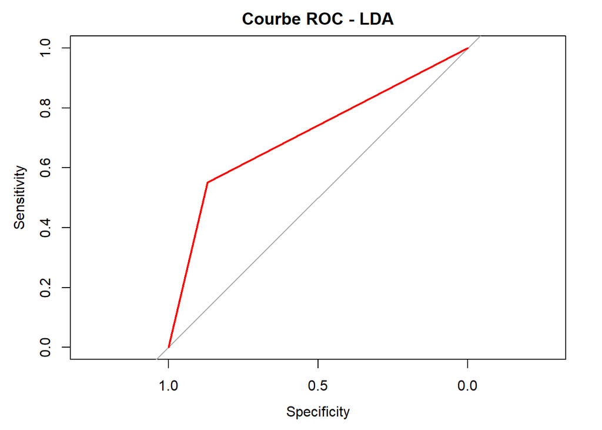

```r
plot(roc_lda, col = "red", lwd = 2, main = "Courbe ROC - LDA")
```

On a un auc de 0.7103, ce qui implique que si on prend au hasard un patient décédé et un patient survivant, le modèle a environ 71 % de chances d’attribuer un score de risque plus élevé au patient décédé.

# 12 ARBRE DE DECISION

```r
cart_model <- rpart(DEATH_EVENT ~., data = HeartFailure_Train, method="class", parms=list(split="gini"))
cart_model
```

```
## n= 209
##
## node), split, n, loss, yval, (yprob)
##       * denotes terminal node
##
##  1) root 209 67 0 (0.67942584 0.32057416)
##    2) time>=73.5 154 21 0 (0.86363636 0.13636364)
##      4) ejection_fraction>=27.5 131 10 0 (0.92366412 0.07633588) *
##      5) ejection_fraction< 27.5 23 11 0 (0.52173913 0.47826087)
##       10) serum_creatinine< 1.15 10  2 0 (0.80000000 0.20000000) *
##       11) serum_creatinine>=1.15 13  4 1 (0.30769231 0.69230769) *
##    3) time< 73.5 55  9 1 (0.16363636 0.83636364) *
```

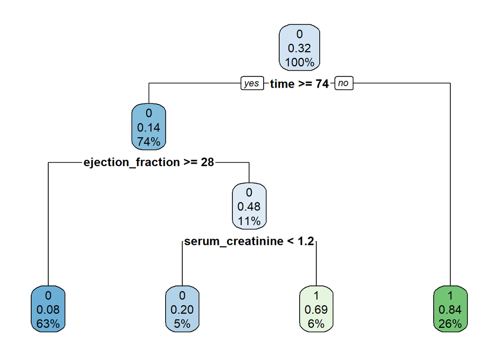

```r
#jpeg("Data_output/arbre_decision.jpg", width = 1200, height = 800, res = 150)
rpart.plot(cart_model)
```

```r
#dev.off()
```

On commence par 100% de notre échantillon. La modalité la plus représentée est 0(survie) et la modalité 1(decès) représente 32% de l’échantillon.

## 12.1 Elagage de l’arbre

```r
cart = rpart(DEATH_EVENT ~., data = HeartFailure_Train, method="class", parms=list(split="gini"),cp=0)
printcp(cart)
```

```
##
## Classification tree:
## rpart(formula = DEATH_EVENT ~ ., data = HeartFailure_Train, method = "class",
##     parms = list(split = "gini"), cp = 0)
##
## Variables actually used in tree construction:
## [1] ejection_fraction serum_creatinine  serum_sodium      time
##
## Root node error: 67/209 = 0.32057
##
## n= 209
##
##          CP nsplit rel error  xerror     xstd
## 1 0.5522388      0   1.00000 1.00000 0.100701
## 2 0.0373134      1   0.44776 0.46269 0.076691
## 3 0.0074627      3   0.37313 0.53731 0.081475
## 4 0.0000000      5   0.35821 0.58209 0.084064
```

## 12.2 choix valeur coefficient de pénalisation de la complexité pour élagage

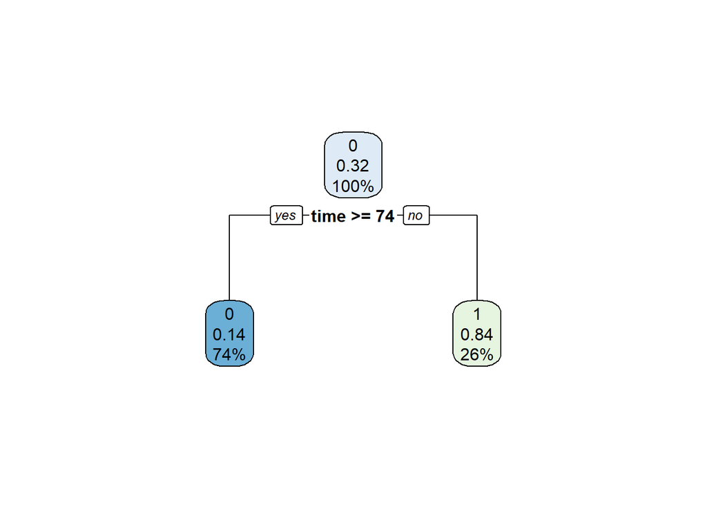

```r
cart_model_3f = rpart(DEATH_EVENT ~., data = HeartFailure_Train, method="class", parms=list(split="gini"),control=list(minbucket=30,minsplit=30*2,maxdepth=3))
rpart.plot(cart_model_3f)
```

Avec la complexité on arrive à 2 feuille qui correspond exactement au nombre de groupe de notre variable cible

## 12.3 Evaluation : Arbre de décision

```r
cart_test_prediction <- predict(cart_model, HeartFailure_Test, type="class")
cart_test_prediction
```

```
##   2   3   8  12  15  18  19  28  31  37  38  44  45  47  49  56  62  65  66  68
##   1   1   1   1   1   1   1   1   1   1   1   1   1   1   1   1   1   1   1   1
##  71  80  82  92  95  96  97  99 100 103 114 117 119 120 123 124 129 132 133 138
##   1   0   0   0   0   0   1   1   0   0   0   0   0   0   0   0   0   0   0   1
## 146 148 150 156 162 167 169 171 176 177 183 184 186 187 188 189 194 196 198 202
##   0   0   0   1   0   0   0   0   0   0   1   0   0   0   1   0   0   0   0   0
## 203 207 208 212 214 219 222 226 230 231 238 242 243 245 247 248 251 259 261 264
##   0   0   0   0   0   0   0   0   1   0   0   0   0   0   0   1   0   0   0   0
## 266 267 269 274 277 278 280 282 294 299
##   0   1   0   0   0   0   0   0   0   0
## Levels: 0 1
```

```r
# Matrice de confusion : CART algorithm
confusion_matrix_cart <- confusionMatrix(table(cart_test_prediction, HeartFailure_Test_labels))
print(confusion_matrix_cart)
```

```
## Confusion Matrix and Statistics
##
##                     HeartFailure_Test_labels
## cart_test_prediction  0  1
##                    0 51  9
##                    1 10 20
##
##                Accuracy : 0.7889
##                  95% CI : (0.6901, 0.8679)
##     No Information Rate : 0.6778
##     P-Value [Acc > NIR] : 0.01376
##
##                   Kappa : 0.521
##
##  Mcnemar's Test P-Value : 1.00000
##
##             Sensitivity : 0.8361
##             Specificity : 0.6897
##          Pos Pred Value : 0.8500
##          Neg Pred Value : 0.6667
##              Prevalence : 0.6778
##          Detection Rate : 0.5667
##    Detection Prevalence : 0.6667
##       Balanced Accuracy : 0.7629
##
##        'Positive' Class : 0
##
```

```r
# Accuracy
accuracy_cart  <- confusion_matrix_cart$overall["Accuracy"]
cat("Accuracy CART is :", accuracy_cart)
```

```
## Accuracy CART is : 0.7888889
```

En général, notre modèle arrive à être précis à 78,89%, ce qui constitue une amélioration par rapport au modèle précédent.

## 12.4 Courbe de ROC

```r
# Tracer la courbe ROC
roc_curve_cart <- roc(cart_test_prediction, HeartFailure_Test_labels)
auc_cart_val <- auc(roc_curve_cart)
print(auc_cart_val)
```

```
## Area under the curve: 0.7583
```

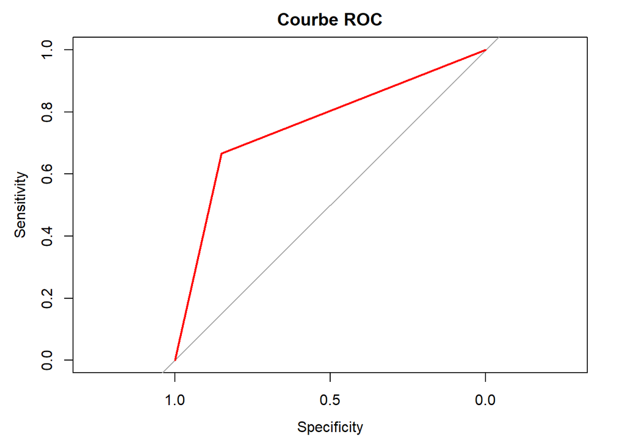

```r
plot(roc_curve_cart, main = "Courbe ROC", col = "red", lwd = 2)
```

On a un auc de 0.7583, ce qui implique que si on prend au hasard un patient décédé et un patient survivant, le modèle a environ 76 % de chances d’attribuer un score de risque plus élevé au patient décédé.

# 13 RANDOM FOREST

```r
library(randomForest)
```

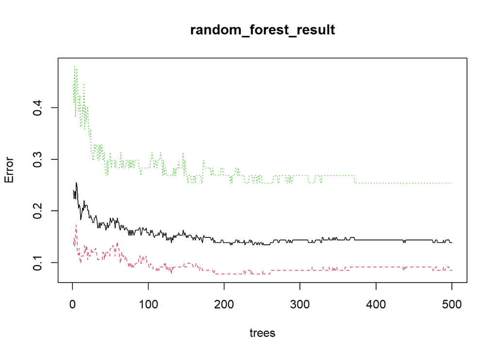

```r
random_forest_result <- randomForest(as.factor(DEATH_EVENT)~.,data=HeartFailure_Train,ntree=500)
plot(random_forest_result)
```

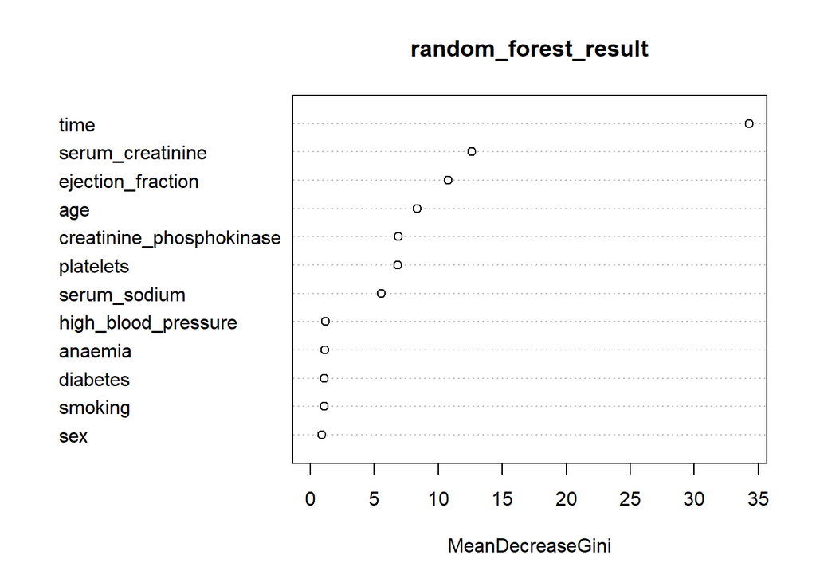

```r
# Variables les plus importants/plus utilisées dans la ségmentation

varImpPlot(random_forest_result)
```

La forêt aléatoire nous montre les variables les plus important de notre modèle à savoir time, serum_creatine, ejection_fraction, age, platelets

## 13.1 Evaluation du RAMDON FOREST

```r
# Prédiction
random_forest_test_prediction <- predict(random_forest_result,HeartFailure_Test,type="class")

confusion_matrix_random_forest <- random_forest_result$confusion[,-3]
confusion_matrix_random_forest
```

```
##     0  1
## 0 130 12
## 1  17 50
```

```r
#mean(Pima.tr$type!=pred.rf)

# Accuracy
accuracy_random_forest  <- sum(diag(confusion_matrix_random_forest)) / sum(confusion_matrix_random_forest)
cat("Accuracy RANDOM FOREST is :", accuracy_random_forest)
```

```
## Accuracy RANDOM FOREST is : 0.861244
```

Pour les non survivants, notre modèle catégorise 17 non survivants qui en réalité ont survécu et il arrive à classer 50 non survivants qui sont bien décédés.

## 13.2 Courbe de ROC

```r
roc_curve_random_forest <- roc(as.numeric(random_forest_test_prediction), HeartFailure_Test_labels)
auc_radom_forest_val <- auc(roc_curve_random_forest)
print(auc_radom_forest_val)
```

```
## Area under the curve: 0.7873
```

```r
cat("\n")
```

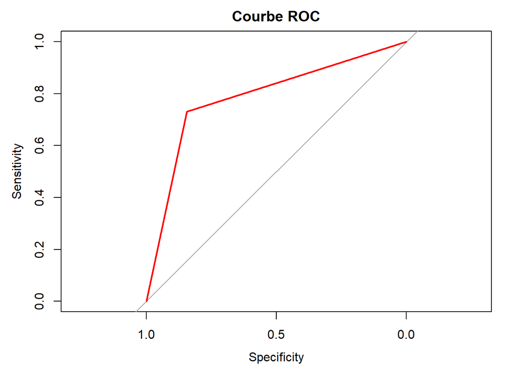

```r
plot(roc_curve_random_forest, main = "Courbe ROC", col = "red", lwd = 2)
```

# 14 SVM

```r
library(e1071)
calibration_result <- tune.svm(DEATH_EVENT~.,data=HeartFailure_Train,gamma=seq(0.001,1,by=0.01))
calibration_result
```

```
##
## Parameter tuning of 'svm':
##
## - sampling method: 10-fold cross validation
##
## - best parameters:
##  gamma
##  0.041
##
## - best performance: 0.1368646
```

```r
svm_result<- svm(as.factor(DEATH_EVENT)~.,data=HeartFailure_Train,gamma=calibration_result$best.parameters)
svm_result
```

```
##
## Call:
## svm(formula = as.factor(DEATH_EVENT) ~ ., data = HeartFailure_Train,
##     gamma = calibration_result$best.parameters)
##
##
## Parameters:
##    SVM-Type:  C-classification
##  SVM-Kernel:  radial
##        cost:  1
##
## Number of Support Vectors:  116
```

## 14.1 Evaluation : SVM

```r
# Prédiction
pred.svm <- predict(svm_result,HeartFailure_Test)
pred.svm
```

```
##   2   3   8  12  15  18  19  28  31  37  38  44  45  47  49  56  62  65  66  68
##   1   1   0   1   1   1   1   1   1   1   1   0   0   1   1   1   0   0   1   1
##  71  80  82  92  95  96  97  99 100 103 114 117 119 120 123 124 129 132 133 138
##   0   0   0   0   0   0   1   1   0   1   0   0   0   1   0   0   0   1   0   1
## 146 148 150 156 162 167 169 171 176 177 183 184 186 187 188 189 194 196 198 202
##   0   0   0   0   0   0   0   0   0   0   0   0   0   0   0   0   0   0   0   0
## 203 207 208 212 214 219 222 226 230 231 238 242 243 245 247 248 251 259 261 264
##   0   0   0   0   0   0   0   0   0   0   0   0   0   0   0   0   0   0   0   0
## 266 267 269 274 277 278 280 282 294 299
##   0   0   0   0   0   0   0   0   0   0
## Levels: 0 1
```

```r
#mean(svm_result$DEA!=pred.svm)# Taux d'erreur de 0.2108434
```

```r
# Matrice de confusion : CART algorithm
confusion_matrix_svm <- confusionMatrix(table(pred.svm, HeartFailure_Test_labels))
print(confusion_matrix_svm)
```

```
## Confusion Matrix and Statistics
##
##         HeartFailure_Test_labels
## pred.svm  0  1
##        0 55 14
##        1  6 15
##
##                Accuracy : 0.7778
##                  95% CI : (0.6779, 0.8587)
##     No Information Rate : 0.6778
##     P-Value [Acc > NIR] : 0.02489
##
##                   Kappa : 0.4516
##
##  Mcnemar's Test P-Value : 0.11752
##
##             Sensitivity : 0.9016
##             Specificity : 0.5172
##          Pos Pred Value : 0.7971
##          Neg Pred Value : 0.7143
##              Prevalence : 0.6778
##          Detection Rate : 0.6111
##    Detection Prevalence : 0.7667
##       Balanced Accuracy : 0.7094
##
##        'Positive' Class : 0
##
```

```r
# Accuracy
accuracy_svm  <- confusion_matrix_cart$overall["Accuracy"]
cat("Accuracy SVM is :", accuracy_svm)
```

[output not shown]

## 14.2 Courbe de roc

```r
roc_curve_svm <- roc(as.numeric(pred.svm), HeartFailure_Test_labels)
auc_svm_val <- auc(roc_curve_svm)
print(auc_svm_val)
```

```
## Area under the curve: 0.7557
```

```r
cat("\n")
```

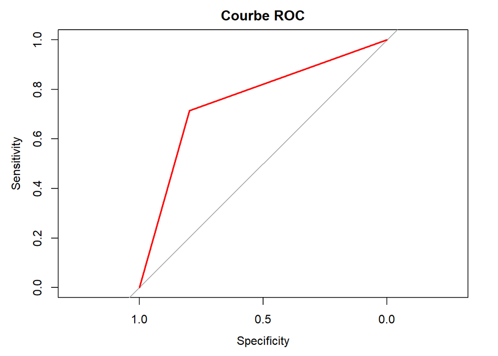

```r
plot(roc_curve_svm, main = "Courbe ROC", col = "red", lwd = 2)
```

# 15 CONCLUSION

```r
list_scoring_model <- c("cah", "kmean", "knn", "lda", "cart", "random forest", "svm")
list_scoring_accuracy <- c(accuracy_cah, accuracy_kMeans, accuracy_knn, accuracy_lda, accuracy_cart, accuracy_random_forest, accuracy_svm)

table_scoring <- data.frame("modèle" = list_scoring_model, "accuracy" = list_scoring_accuracy)
table_scoring
```

[output not shown]

On peut conclure que le modèle de Random Forest est le modèle de scoring le plus performant pour prédire la probabilité de décéder de suite d’une insuffisante cardiaque au regard de l’accuracy : 0.861244. Par ailleurs, ce dernier a été utilisé pour identifier les variables qui influencent le plus ce phénomène. Il résulte de cette analyse que le temps après l’insuffisance cardiaque (exprimée en nombre de jour), le taux de créatinine, la fraction d’éjection et l’âge sont les facteurs les plus déterminants.